# Emotional Landscape of Empirical Research Projects

Boglarka Ludmany

# Overview - Introduction

# Overall pattern

The overall pattern represents that researchers reported both positive and negative emotional intensity in relation to their work.

## Overall intensity of positive and negative emotions

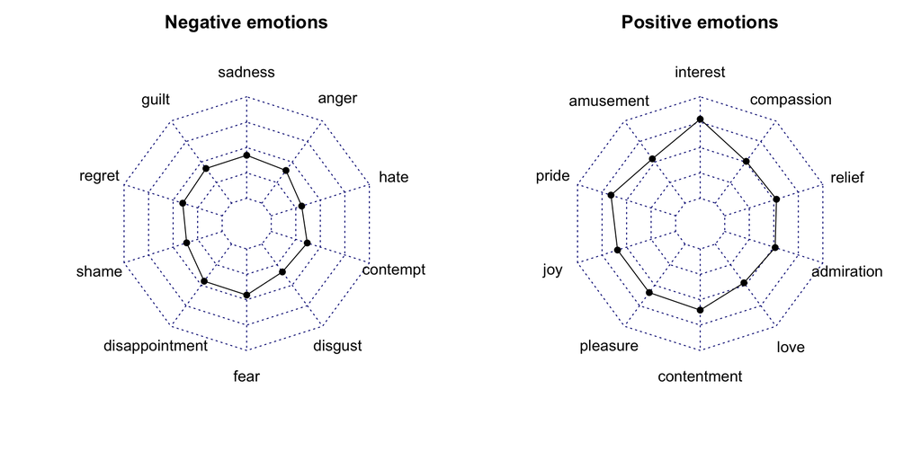

As can be seen on the radar charts, positive emotions tended to be more intensely experienced than negative emotions. Interest was reported with the greatest intensity, followed by pride and contentment. Among negative emotions, fear and disappointment exhibited the highest mean intensity.

## Intensity of general feeling throughout the research stages

Regarding the intensity of the overall emotional state (represented on a scale of -3 to 3), the visualization includes a distribution of the reported general feeling scores.

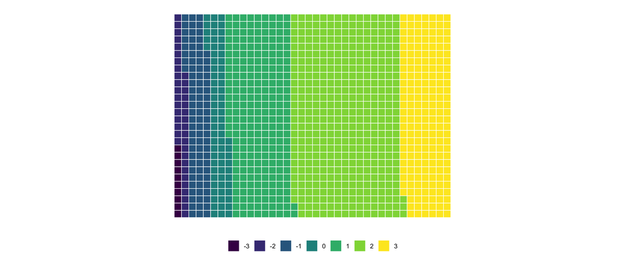

The plot shows the proportional distribution of the general feeling scores, with each value divided by 15 (in order to represent its relative contribution to the overall score). The most frequent values were 1 and 2; positive values carry considerably greater weight in the distribution, whereas negative values are relatively uncommon.

# Overall emotional landscape by research stage

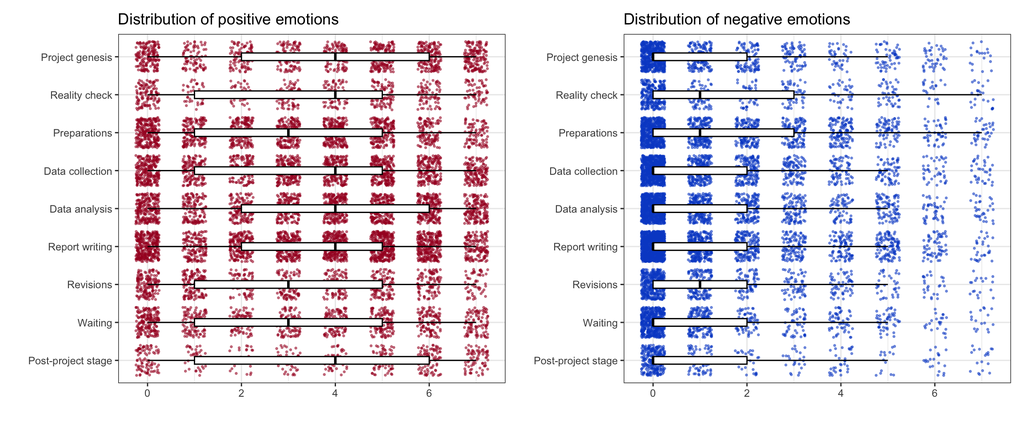

The plots depict all negative and positive emotions reported in each research stage. The jittering represents the amounts of observations in each grade of the intensity scale. Overall, it is clear that positive emotions were reported more intensely than negative emotions: higher scores are more frequent, the conditional means (by research stage) are substantially higher than that of the negative emotions. With regards to negative emotions, lower scores are more frequent. (It is noteworthy that this data frame contains the emotions that were reported as *not felt*, therefore their intensity was 0. Consequently, this might have influenced the distribution of the intensity of positive and negative emotions.)

### Distributions of specific emotions

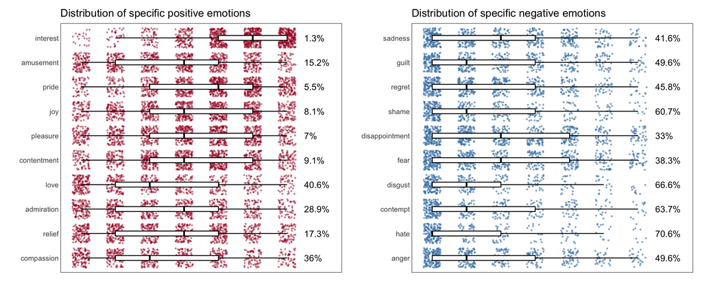

The plots illustrate the intensity of specific positive and negative emotions. The x axis represents the 1-7 discrete scale, the frequency of each reported value is represented by the jittered data points. The percentage of the reported 0 values regarding each emotion is placed (0 values express the emotion not being felt) on the right side of each plot. Lower and 0 scores within negative emotions were more frequent, however, fear and disappointment were relatively prevalent.

### Trends in positive and negative emotions

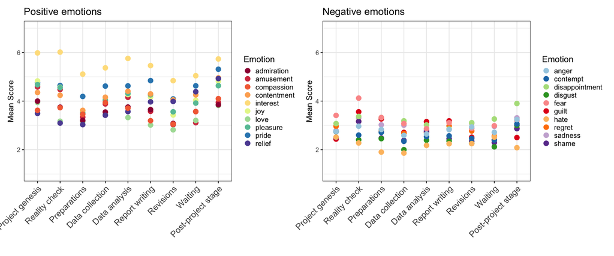

### Post-project stage

The Post-project stage was divided into 3 categories, depending on the outcome of the submission/future of the project: Accepted and published; Accepted but not yet published; Rejected (rejected and postponed, rejected and abandoned, rejected and being revised). The three subgroups of the Rejected category were merged due to the small sample size (*N* = 12), therefore the results should be interpreted carefully.

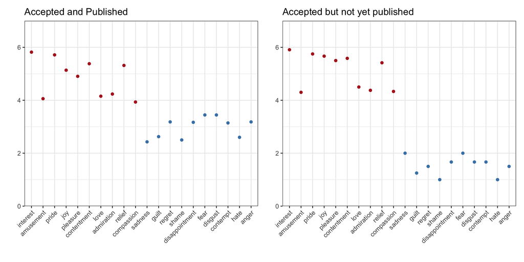

However, it is important to mention that the sample size of the *“Accepted but not yet published”* category is particularly small: *N* = 12, whilst in the *“Accepted and published”* category, the sample size is *N* = 23. The small sample size in the former category represents the exclusion of participants who did not complete the questionnaire.

The values reported as 0 were not included in the data used to create the plots, since the visualizations only represent the emotions that were reported as “felt”.

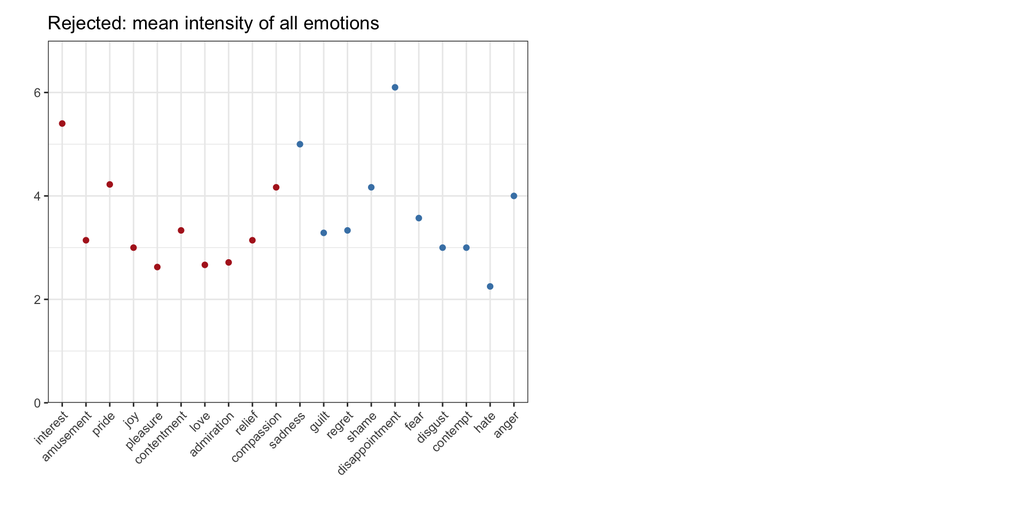

# Emotional Landscape Across Key Variables

When creating the visualizations, the emotions reported as “not felt” (as 0), were not included in the analysis.

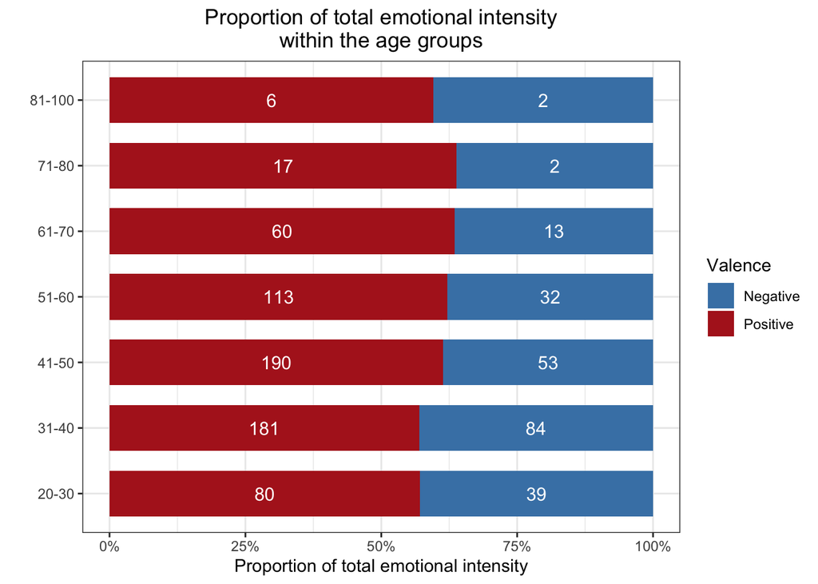

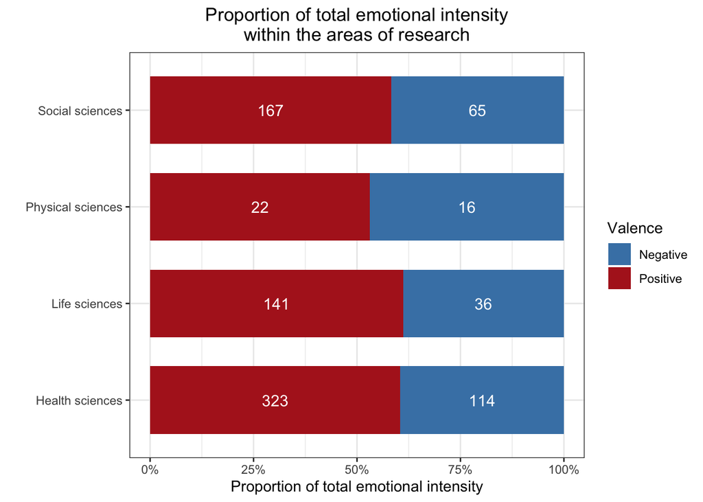

Among different areas of research, the pattern regarding the proportion of positive and negative emotions is consistent with the aforementioned results: positive emotional intensity represents the majority of the total emotional intensity. Nevertheless, it should be noted that compared to the other areas, researchers working in Physical sciences reported a slightly larger proportion of negative emotional intensity.

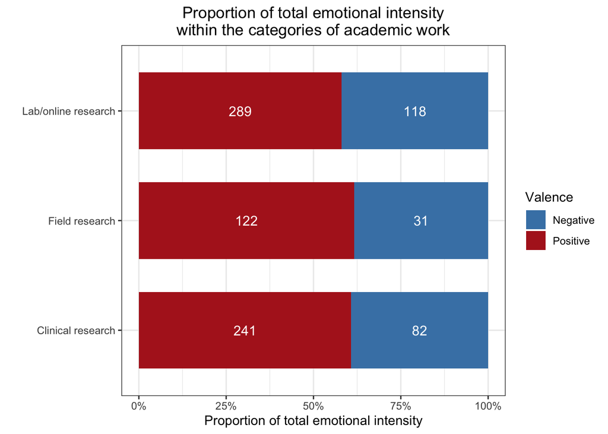

Across all research settings, positive emotions consistently represented the majority of total emotional intensity. A minor difference can be observed in the case of Lab/online research, where the proportion of negative emotions seems to be slightly larger.

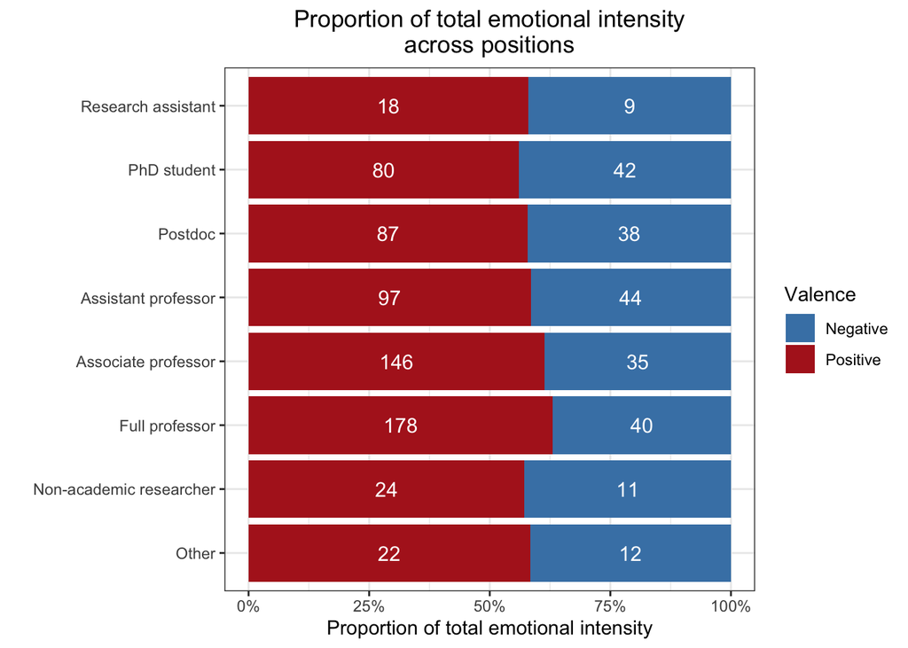

### Countries

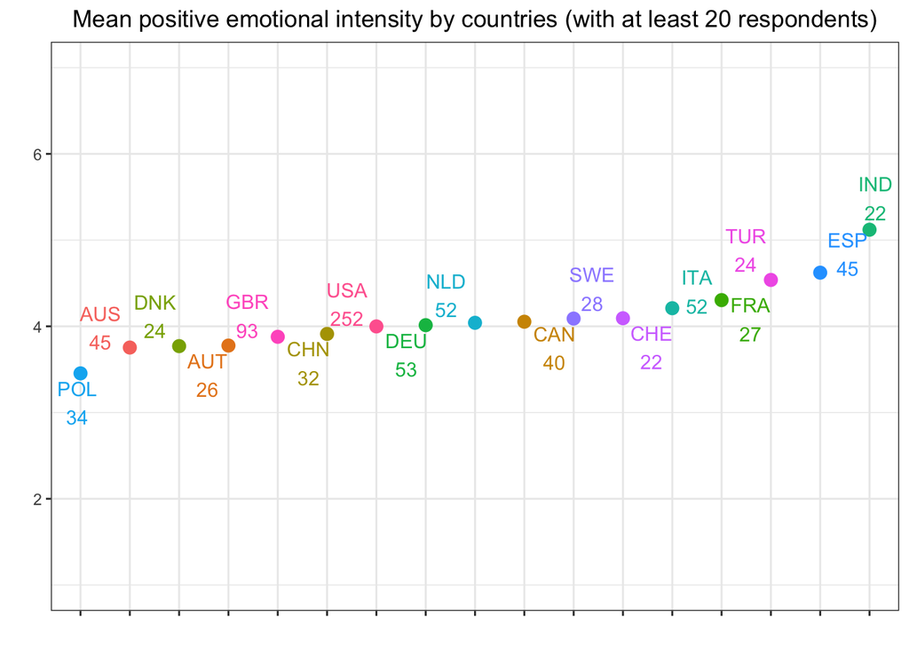

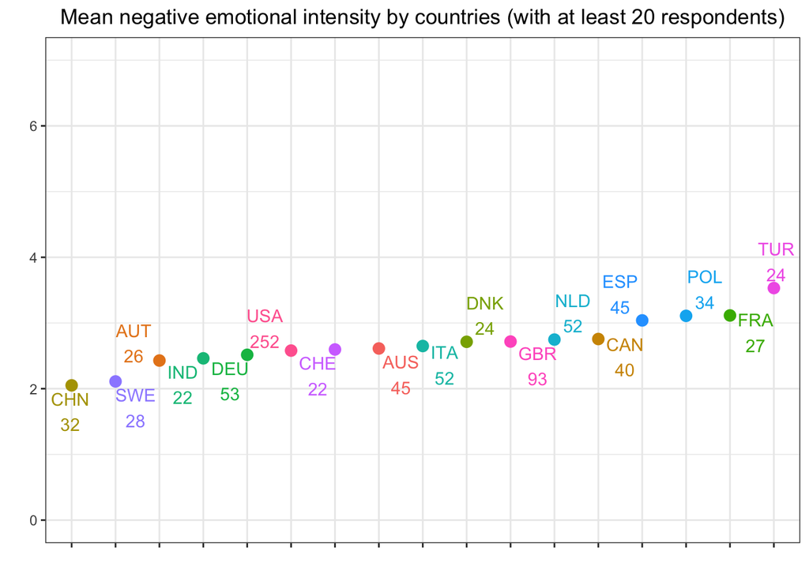

Interestingly, respondents from Turkey reported comparatively high levels of both positive and negative emotional intensity relative to respondents from other countries. Besides Turkish participants, French and Polish respondents also reported similarly higher negative emotional intensity.

# Descriptives

### Questionnaire completion

The following table summarizes questionnaire completion rates.

|  | count |
| --- | --- |
| Not completed | 463 |
| Completed | 1,003 |

### Genders

| gender | n |
| --- | --- |
| Woman | 546 |
| Man | 516 |
| Prefer not to say | 15 |
| Non-binary / third gender / gender non-conforming | 9 |

With regards to gender, female respondents comprised the largest proportion of respondents, followed by male participants. Participants identifying as non-binary or selecting “Prefer not to say” constituted a smaller proportion of the sample.

### Participants by research area

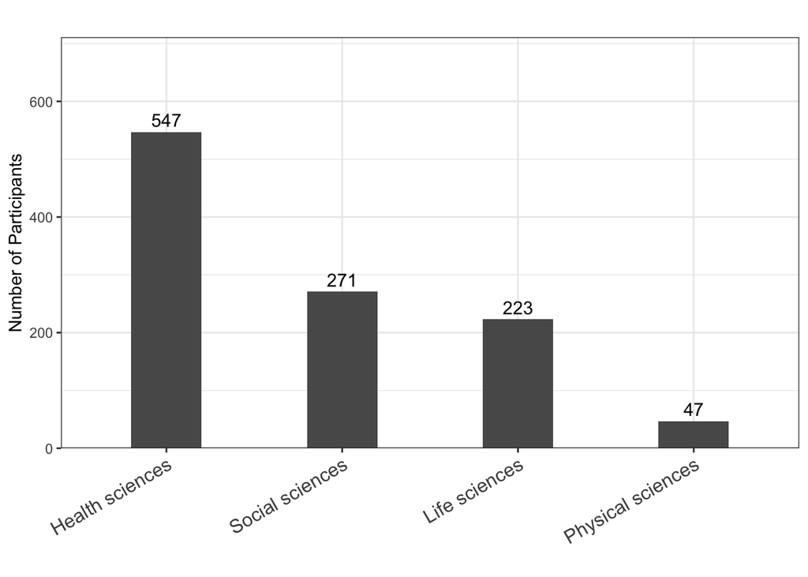

Health scientists represented the largest disciplinary groups, whereas physical scientists represented the smallest.

### Participants by position

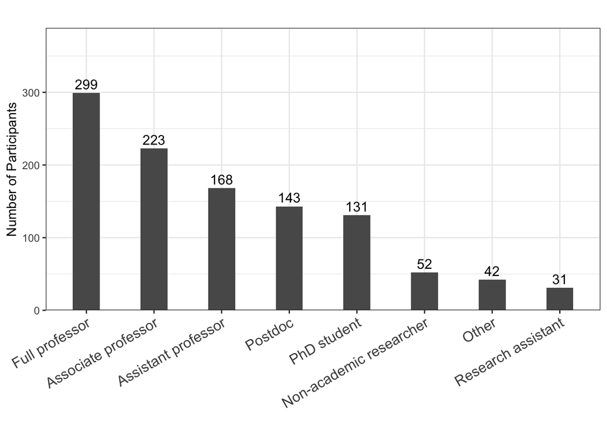

Professors comprised the most sizable position group in the sample (with full professors representing the most largest subgroup), while research assistants constituted the smallest position group.

### Participants by category of work

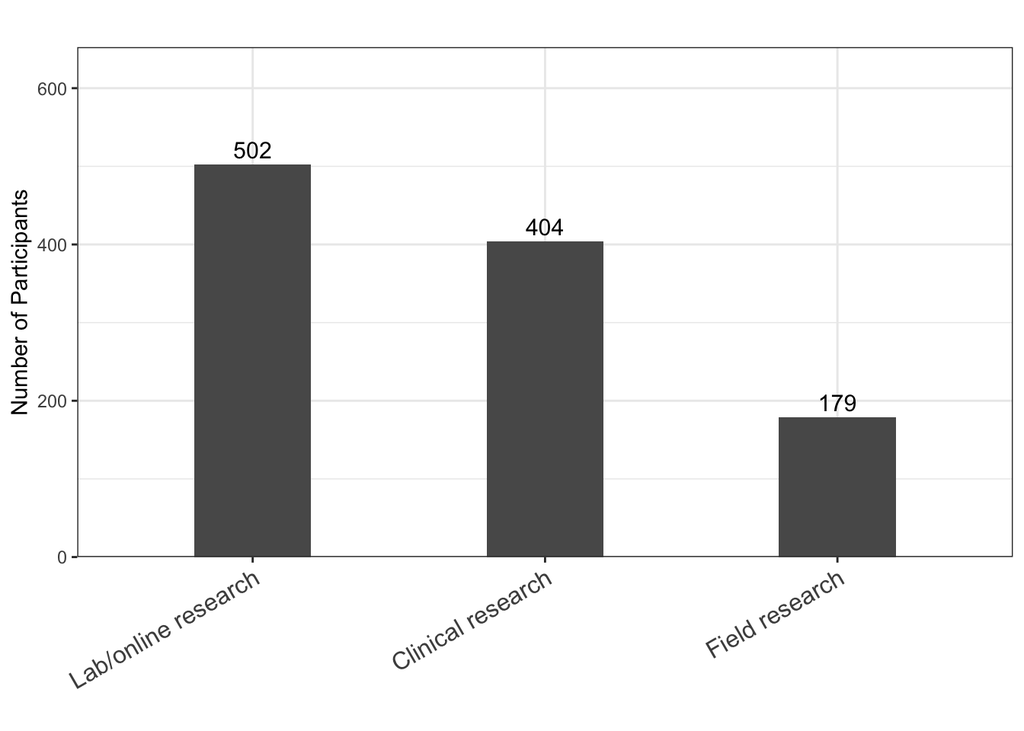

### Country distribution

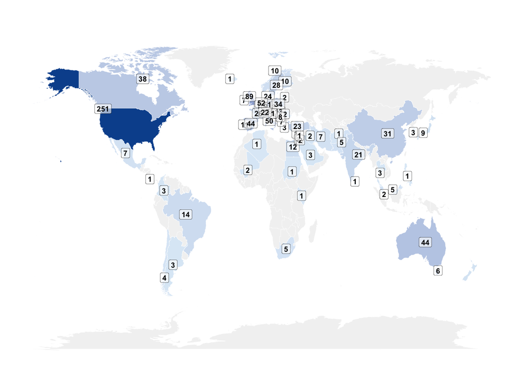

Respondents from the United States of America comprised the largest group in the sample. Although Australia and Canadian were notably represented countries, however, their representation was substantially lower that that of the United States.

Researchers from European countries constituted a substantial proportion of respondents, however, as can be seen on the map, the labels are visually cluttered (probably due to the size of Europe in contrast to the size of the world).  
In order to overcome the issue of the congested labels, a separate plot was created, which visualizes the numbers of respondents from European countries.

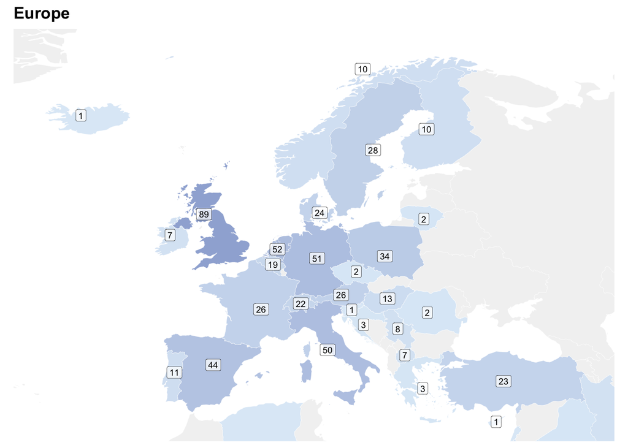